# Aerobic-Incubation

Author

Yendi E. Navarro-Noya and Luc Dendooven

Aerobic incubation experiment (Dendooven, Murphy, and Powlson 2000)

Soil samples were adjusted to 40% WHC with distilled water and conditioned for a week. The soil samples were separately (ca. 10 kg) placed in the 70-l drums containing a 1-l jar with 1.0 mol l-1 NaOH to trap evolved CO2 and a 5-l jar with distilled water to avoid desiccation during storage. A stock solution of (NH4)2SO4 was prepared and was used to apply NH4+-N to the soil.

The aerobic incubation experiment was based on the technique developed by Jenkinson and Powlson (Jenkinson and Powlson 1976) to measure soil microbial biomass C. Five sub-samples of 25 g soil from each plot (n = 3) and the two different agricultural practices (CBR and PBR, n = 2) were added separately to 120 ml glass flasks. One flask from each treatment and plot was selected at random and extracted for mineral N and DNA as described below. These were the zero-time samples. Two different treatments were applied to the remaining soil samples. Two sub-samples (n = 2) from each plot (n = 3) were amended with 300 mg NH4+-N kg-1 soil (considered the ammonium amended soil) and two samples (n = 2) were left unamended (considered the unamended or control soil).

Each flask was placed in a 1-l glass jar containing a 25 ml flask with 20 ml 1.0 mol l-1 NaOH to capture the evolved CO2 and a 25 ml flask filled with distilled water to avoid desiccation of the soil during incubation, and closed air-tight. Additionally, 6 flasks containing a 25 ml flask with 20 ml 1.0 mol l-1 NaOH and a 25 ml flask filled with distilled water, but without soil were closed air-tight and served as control to account for the CO2 captured from the headspace of the flasks.

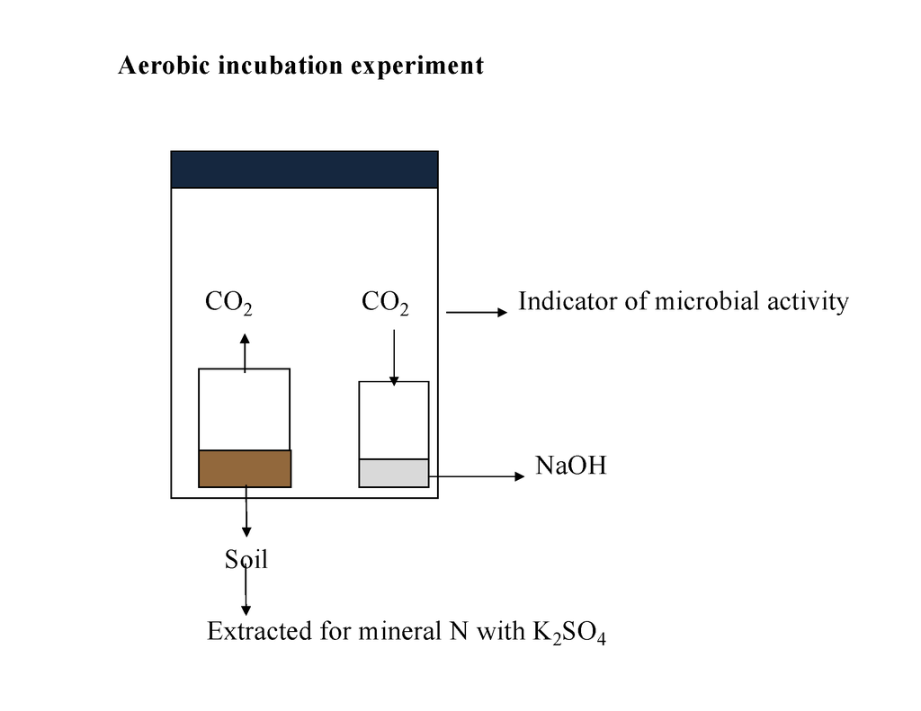

Aerobic incubation

After 3 and 14 days, one jar from each plot (n = 3), treatment (n = 2) left unamended or amended with 300 mg NH4+-N kg-1 were selected at random, opened, the 25 ml flask with 1.0 mol l-1 NaOH taken out and analyzed for CO2 (Jenkinson and Powlson 1976). Three flasks without soil were also opened and the CO2 captured in the NaOH measured. The soil was removed from the flask, and a 5 g subsample was kept and extracted for DNA as described below, while the rest was extracted for mineral N (NH4+, NO2- and NO3-) with 80 ml 0.5 mol l-1 K2SO4. The K2SO4 extract was then analyzed for mineral N on a San Plus System-SKALAR automatic analyzer (Skalar, Breda, the Netherlands) (Mulvaney 1996). The total C in the K2SO4 extract was measured by wet combustion with potassium dichromate in the presence of concentrated sulfuric acid (Vance, Brookes, and Jenkinson 1987). The remaining flasks were opened, aired for 10 min, closed air-tight and incubated for another 11 days.

A 0.5 g subsample of each soil sample (n = 30) was extracted for DNA using the QIAGEN kit as stipulated by the provider. Aliquots of 2 mL of each sample were centrifuged at 12000 * g for 5 min, the pellets were resuspended in 200 μL sterile distilled water, 180 μL lysozyme (20 mg/mL) was added to each tube and incubated at 37 °C for 1 h. The samples were processed by the QIAcube-robot with the QIAamp DNA Mini (Qiagen, Venlo, The Netherlands) and eluted to a final volume of 200 μL water.

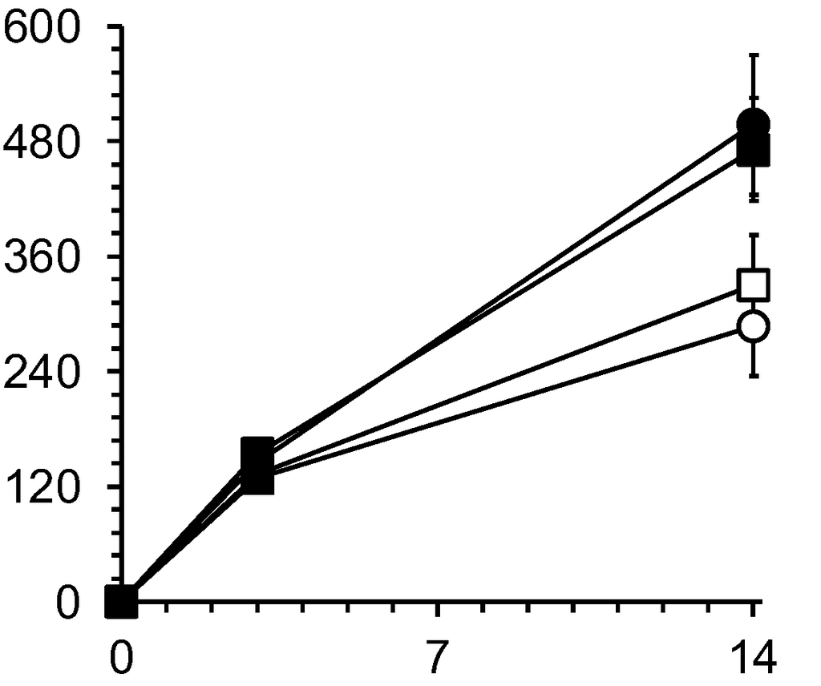

Emitted CO2

## References

Dendooven, L, E Murphy, and DS Powlson. 2000. “Failure to Simulate c and n Mineralization in Soil Using Biomass c-to-n Ratios as Measured by the Fumigation Extraction Method?” *Soil Biology and Biochemistry* 32 (5): 659–68.

Jenkinson, David S, and David S Powlson. 1976. “The Effects of Biocidal Treatments on Metabolism in Soil—v: A Method for Measuring Soil Biomass.” *Soil Biology and Biochemistry* 8 (3): 209–13.

Mulvaney, Richard L. 1996. “Nitrogen—Inorganic Forms.” *Methods of Soil Analysis: Part 3 Chemical Methods* 5: 1123–84.

Vance, Eric D, Peter C Brookes, and David S Jenkinson. 1987. “An Extraction Method for Measuring Soil Microbial Biomass c.” *Soil Biology and Biochemistry* 19 (6): 703–7.